# QPot: An R Package for Stochastic Differential Equation Quasi-Potential Analysis

## Step 6: Vector field decomposition

Recall that the deterministic skeleton @ref(eq:Deterministic) can be visualized as a vector field, as shown in Figure 1. In gradient systems, this vector field is completely determined by the potential function, $V(x,y)$. The name gradient system refers to the fact that the vector field is the negative of the potential function’s gradient,
$$\begin{aligned}
\begin{bmatrix}f_{1}(x,y)\\ f_{2}(x,y) \end{bmatrix}&=-\nabla
V(x,y)= -\begin{bmatrix}\frac{\partial V}{\partial x}(x,y)\\
\frac{\partial V}{\partial y}(x,y) \end{bmatrix}.
\end{aligned}$$
In non-gradient systems, the vector field can no longer be represented solely in terms of the gradient of $\Phi(x,y).$ Instead, there is a remainder component of the vector field, $\mathbf{r}(x,y)=\begin{bmatrix}r_{1}(x,y)\\ r_{2}(x,y) \end{bmatrix}.$ The vector field can be decomposed into two terms:
$$\begin{aligned}
\begin{bmatrix}f_{1}(x,y)\\ f_{2}(x,y) \end{bmatrix}&=-\nabla
\Phi(x,y)+\mathbf{r}(x,y)= -\begin{bmatrix}\frac{\partial \Phi}{\partial
x}(x,y)\\ \frac{\partial \Phi}{\partial y}(x,y) \end{bmatrix} +
\begin{bmatrix}r_{1}(x,y)\\ r_{2}(x,y) \end{bmatrix}.
\end{aligned}$$
The remainder vector field is orthogonal to the gradient of the quasi-potential everywhere. That is, for every $(x,y)$ in the domain,
$$\begin{aligned}
\nabla\Phi(x,y)\cdot\mathbf{r}(x,y)&=0.
\end{aligned}$$
An explanation of this property can be found in Nolting and Abbott (2016).

The remainder vector field can be interpreted as a force that causes trajectories to circulate around level sets of the quasi-potential. *QPot* enables users to perform this decomposition. The function `VecDecomAll()` calculates the vector field decomposition, and outputs three vector fields: the original deterministic skeleton, $\mathbf{f}(x,y)$; the gradient vector field, $-\nabla\Phi(x,y)$; and the remainder vector field, $\mathbf{r}(x,y)$. Each of these three vector fields can be output alone using `VecDecomVec()`, `VecDecomGrad()`, or `VecDecomRem()`. These vector fields can be visualized using the function `VecDecomPlot()`. Code to create the vector fields from `VecDecomAll()` is displayed below; code for generating individual vector fields can be found in the man pages accessible by `help()` for `VecDecomVec()`, `VecDecomGrad()`, or `VecDecomRem()`. The gradient and remainder vector fields are shown in the left and right columns of Figure 6, respectively, with proportional vectors (top row) and equal-length vectors (bottom row). Three arguments within `VecDecomPlot()` are important to creating comprehensible plots: `dens`, `tail.length`, and `head.length`. The `dens` parameter specifies the number of arrows in the plot window along the $x$ and $y$ axes. The argument `tail.length` scales the length of arrow tails. The argument `head.length` scales the length of arrow heads. The function `arrows()` makes up the base of `VecDecomPlot()`, and arguments can be passed to it, as well as to `plot()`. The code below produces all three vector fields from the multi-dimensional array returned by `VecDecomAll()`:

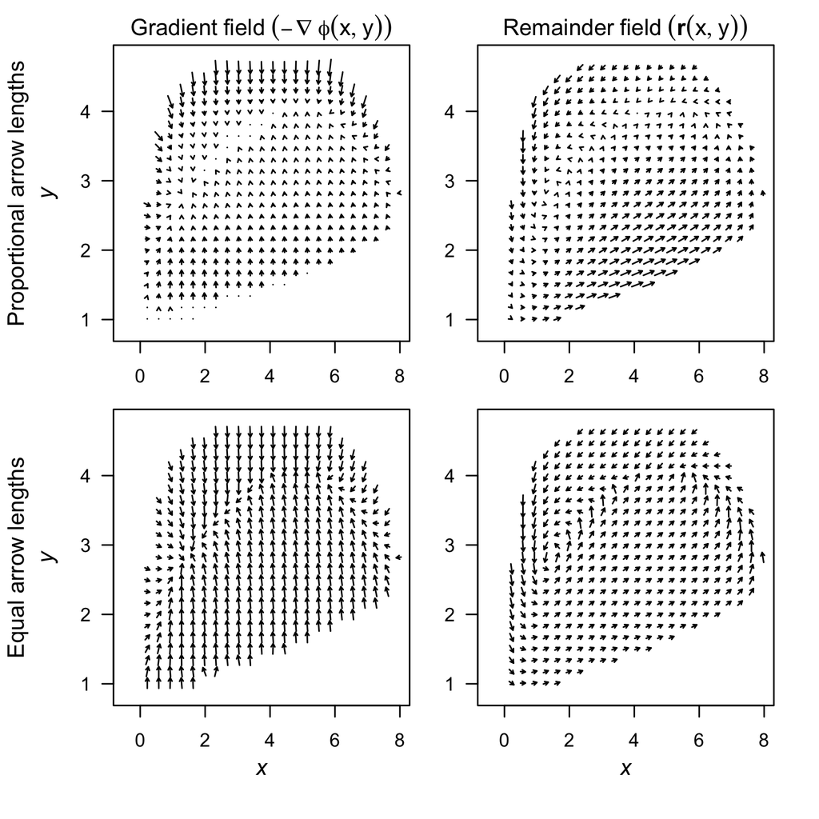

Figure 6: The gradient (left column) and remainder (right column) fields, plotted with `arrow.type = "proportional"` (top row) and `arrow.type = "equal"` (bottom row) arrow lengths using `VecDecomPlot()` for System @ref(eq:ex1).

```r
## Calculate all three vector fields.
VDAll <- VecDecomAll(surface = ex1.global, x.rhs = parms.eqn.x, y.rhs = parms.eqn.y,
  x.bound = bounds.x, y.bound = bounds.y)
## Plot the deterministic skeleton vector field.
VecDecomPlot(x.field = VDAll[, , 1], y.field = VDAll[, , 2], dens = c(25, 25),
  x.bound = bounds.x, y.bound = bounds.y, xlim = c(0, 11), ylim = c(0, 6),
  arrow.type = "equal", tail.length = 0.25, head.length = 0.025)
## Plot the gradient vector field.
VecDecomPlot(x.field = VDAll[, , 3], y.field = VDAll[, , 4], dens = c(25, 25),
  x.bound = bounds.x, y.bound = bounds.y, arrow.type = "proportional",
  tail.length = 0.25, head.length = 0.025)
## Plot the remainder vector field.
VecDecomPlot(x.field = VDAll[, , 5], y.field = VDAll[, , 6], dens = c(25, 25),
  x.bound = bounds.x, y.bound = bounds.y, arrow.type = "proportional",
  tail.length = 0.35, head.length = 0.025)
```

# Example 2: A model with a limit cycle

Consider the following model:
$$\label{ex2}
\begin{split}
dX(t)&=\left(-(Y(t)-\beta
)+\mu\,(X(t)-\alpha)\left(1-(X(t)-\alpha)^{2}-(Y(t)-\beta
)^{2}\right)\right)\, dt+\sigma\, dW_{1}(t) \\
dY(t)&=\left((X(t)-\alpha)+\mu\,(Y(t)-\beta
)\left(1-(X(t)-\alpha)^{2}-(Y(t)-\beta )^{2}\right)\right)\, dt+\sigma\,
dW_{2}(t).
\end{split} (\#eq:ex2)$$
This model will demonstrate *QPot*’s ability to handle limit cycles. We will analyze this example with $\mu=0.2$, $\alpha=4$, and $\beta=5$.

## Step 1: Analyzing the deterministic skeleton

The deterministic skeleton of this system has one equilibrium, $\mathbf{e}_{0}=(4,\,5),$ which is an unstable spiral point. Figure 7 shows a stream plot of the deterministic skeleton of System @ref(eq:ex2). A particular solution of the deterministic skeleton of System @ref(eq:ex2) can be found using *rootSolve* and *deSolve*. The stream plot and a few particular solutions suggest that there is a stable limit cycle. To calculate the limit cycle, one can find a particular solution over a long time interval (e.g., Figure 7 has three trajectories run for $T = 100$). The solution will eventually converge to the limit cycle. One can drop the early part of the trajectory until only the closed loop of the limit cycle remains. There are more elegant ways to numerically find a periodic orbit (even when those orbits are unstable). For more information on these methods, see Chua and Parker (1989). In this example, the limit cycle is shown by the thick black line in Figure 7. For calculation of the quasi-potential, it is sufficient to input a single point that lies on the limit cycle. For this example, one such point is $\mathbf{z}=(4.15611,\,5.98774).$

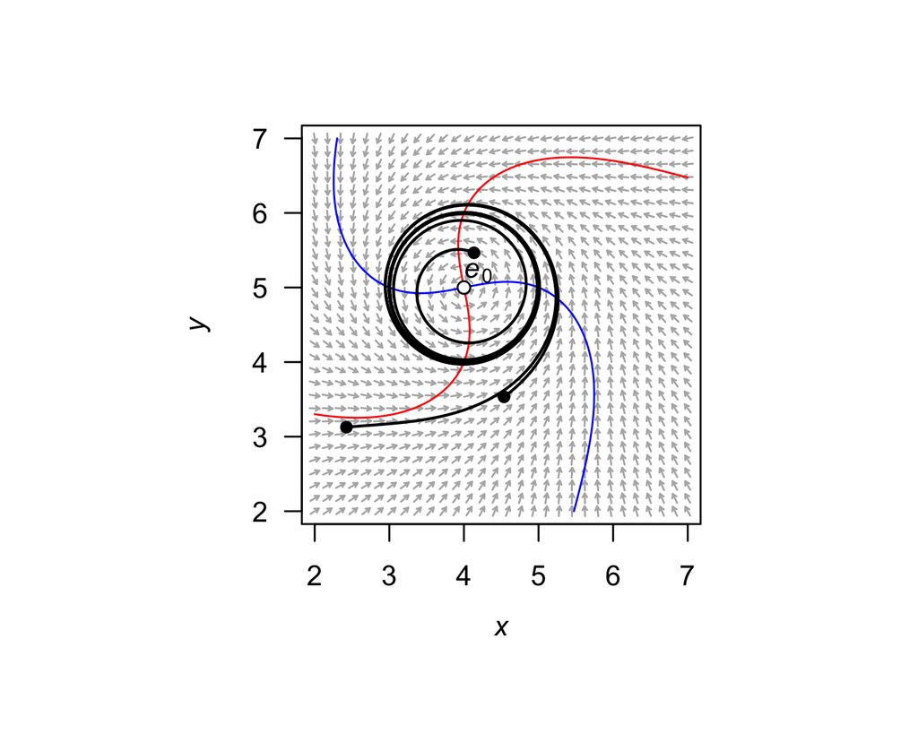

Figure 7: A stream plot of the deterministic skeleton of System @ref(eq:ex2). The blue line is an $x$-nullcline (where $\frac{dx}{dt}=0$) and the red line is a $y$-nullcline (where $\frac{dy}{dt}=0$). The open circle is an unstable equilibrium. Particular solutions are shown as black lines, with filled circles as initial conditions. Made using the package *phaseR*.

## Step 2: Stochastic simulation

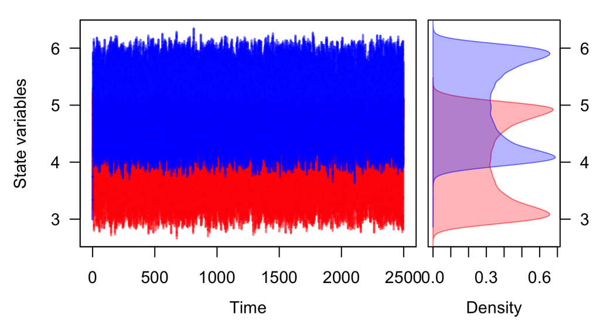

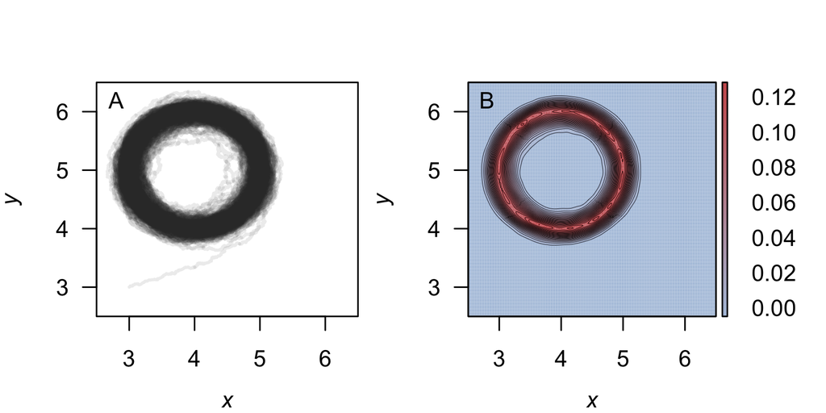

Figure 9: (A) The realization of System @ref(eq:ex2) plotted in $(x,y)$-space (`dim = 2` in the function `TSPlot()`) (B) A density plot obtained from a realization of System @ref(eq:ex2) using `TSDensity()` with `dim = 2`. Red corresponds to high density, and blue to low density.

```r
[commandchars=\\\{\}]
var.eqn.x <- "- (y - beta) + mu * (x - alpha) * (1 - (x - alpha)^2 - (y - beta)^2)"
var.eqn.y <- "(x - alpha) + mu * (y - beta) * (1 - (x - alpha)^2 - (y - beta)^2)"
model.state <- c(x = 3, y = 3)
model.parms <- c(alpha = 4, beta = 5, mu = 0.2)
model.sigma <- 0.1
model.time <- 1000 # we used 2500 in the figures
model.deltat <- 0.005
ts.ex2 <- TSTraj(y0 = model.state, time = model.time, deltat = model.deltat,
  x.rhs = var.eqn.x, y.rhs = var.eqn.y, parms = model.parms, sigma = model.sigma)
TSPlot(ts.ex2, deltat = model.deltat)                 # Figure \ref{fig:ex2ts}
TSPlot(ts.ex2, deltat = model.deltat, dim = 2, line.alpha = 25) # Figure \ref{fig:ex22d}a
TSDensity(ts.ex2, dim = 1)                       # Histogram
TSDensity(ts.ex2, dim = 2)                       # Figure \ref{fig:ex22d}b
```

## Step 3: Local quasi-potential calculation

In this example, there are no stable equilibrium points. There is one stable limit cycle, and this can be used to obtain a local quasi-potential. Using $\mathbf{z}$ as the initial point for the ordered-upwind algorithm and $Lx_{1}=-0.5$, $Ly_{1}=-0.5$, $Lx_{2}=7.5$, $Ly_{2}=7.5$, $N_x=4000$ and $N_y=4000$, one obtains a local quasi-potential, $\Phi_{\mathbf{z}}(x,y)$. The following code generates the local quasi-potential $\Phi_{\mathbf{z}}(x,y)$:

```r
eqn.x <- Model2String(var.eqn.x, parms = model.parms)
eqn.y <- Model2String(var.eqn.y, parms = model.parms)
eq1.qp <- QPotential(x.rhs = eqn.x, x.start = 4.15611, x.bound = c(-0.5, 7.5),
  x.num.steps = 4000, y.rhs = eqn.y, y.start = 5.98774, y.bound = c(-0.5, 7.5),
  y.num.steps = 4000)
```

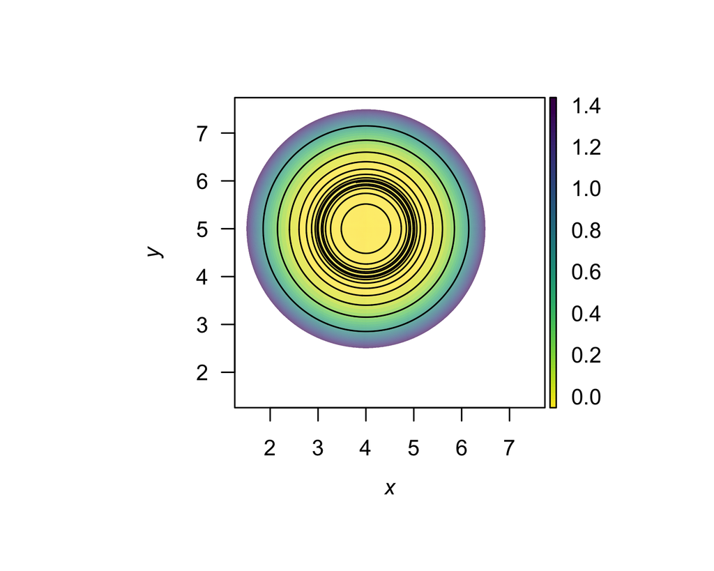

Figure 10: A contour plot of the quasi-potential of System @ref(eq:ex2) using `QPContour()`. Yellow corresponds to low values of the quasi-potential, and purple to high values.

## Step 4: Global quasi-potential calculation

There is only one local quasi-potential in this example, so it is the global quasi-potential, $\Phi(x,y)=\Phi_{\mathbf{z}}(x,y).$

## Step 5: Global quasi-potential visualization

Figure 10 shows a contour plot of the global quasi-potential.

```r
QPContour(eq1.qp, dens = c(1000, 1000), x.bound = c(-0.5, 7.5),
  y.bound = c(-0.5, 7.5), c.parm = 10)
```

# Example 3: More complicated local quasi-potential pasting

In Example 1, the procedure for pasting local quasi-potentials together into a global quasi-potential was a simple, two-step process. First, one of the local quasi-potentials was translated so that the two surfaces agreed at the saddle point separating the two basins of attraction. Second, the global quasi-potential was obtained by taking the minimum of the two surfaces at each point. A general algorithm for pasting local quasi-potentials, as explained in Graham and Tél (1986) and Roy and Nauman (1995), is slightly more complicated. This process is automated in `QPGlobal()`, but it is worth understanding the process in order to correctly interpret the outputs.

To understand the full algorithm, consider the following model:
$$\begin{split}
\label{ex3}
dX(t)&=X(t)\left(\left(1+\alpha_{1}\right)-X(t)^{2}-X(t)\,
Y(t)-Y(t)^{2}\right)\, dt+\sigma\, dW_{1}(t)\\
dY(t)&=Y(t)\left(\left(1+\alpha_{2}\right)-X(t)^{2}-X(t)\,
Y(t)-Y(t)^{2}\right)\, dt+\sigma\, dW_{2}(t).
\end{split} (\#eq:ex3)$$
For this analysis, let $\alpha_{1}=1.25$ and $\alpha_{2}=2.$ We have selected this model because it demonstrates how *QPot* can handle an exceptionally tricky global quasi-potential construction.

## Step 1: Analyzing the deterministic skeleton

The deterministic skeleton of this system has five equilibria. These are $\mathbf{e}_{u1}=(0,0)$, $\mathbf{e}_{s1}=(0,\,-1.73205),$ $\mathbf{e}_{s2}=(0,\,1.73205),$ $\mathbf{e}_{u2}=(-1.5,\,0)$ and $\mathbf{e}_{u3}=(1.5,\,0).$ The eigenvalue analysis shows that $\mathbf{e}_{u1}$ is an unstable node, $\mathbf{e}_{s1}$ and $\mathbf{e}_{s2}$ are stable nodes, $\mathbf{e}_{u2}$ and $\mathbf{e}_{u3}$ are saddles. Figure 11 shows a stream plot of the deterministic skeleton of @ref(eq:ex3). The basin of attraction for $\mathbf{e}_{s1}$ is the lower half-plane, and the basin of attraction for $\mathbf{e}_{s2}$ is the upper half-plane.

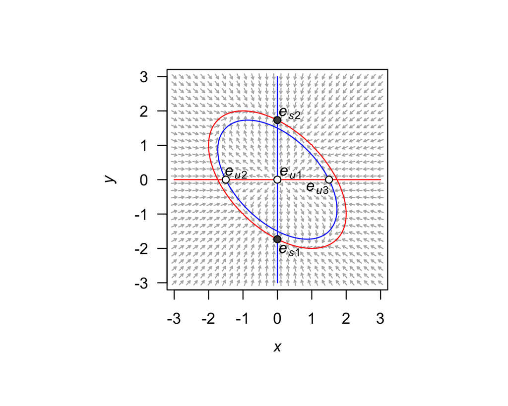

## Step 2: Stochastic simulation

Figures 12 and 13a show a time series for a realization of System @ref(eq:ex3) with $\sigma=0.8$, $\Delta t=0.01$, $T=5000$ and initial condition $(x_{0},\, y_{0})=(0.5,\,0.5).$ Figure 13b shows a density plot of this realization.

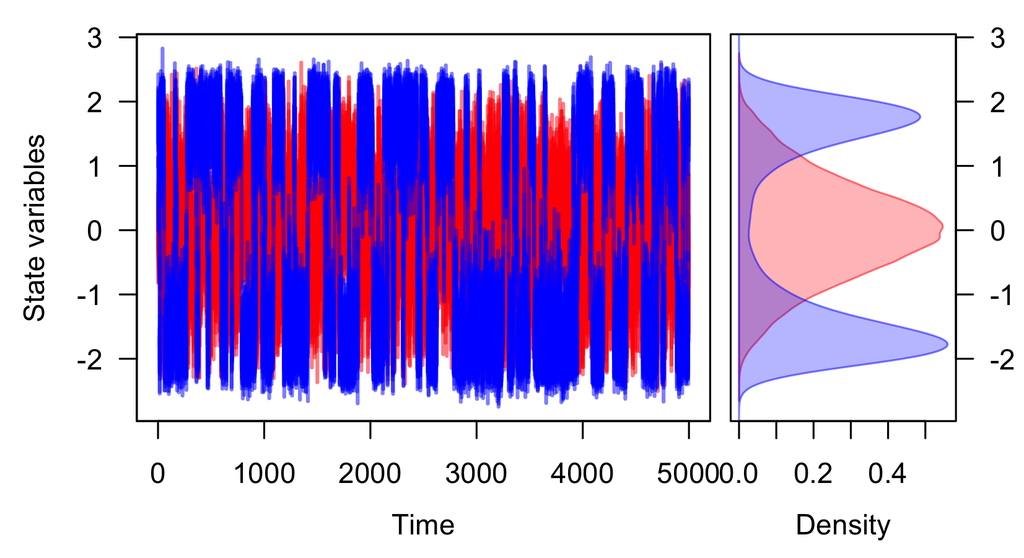

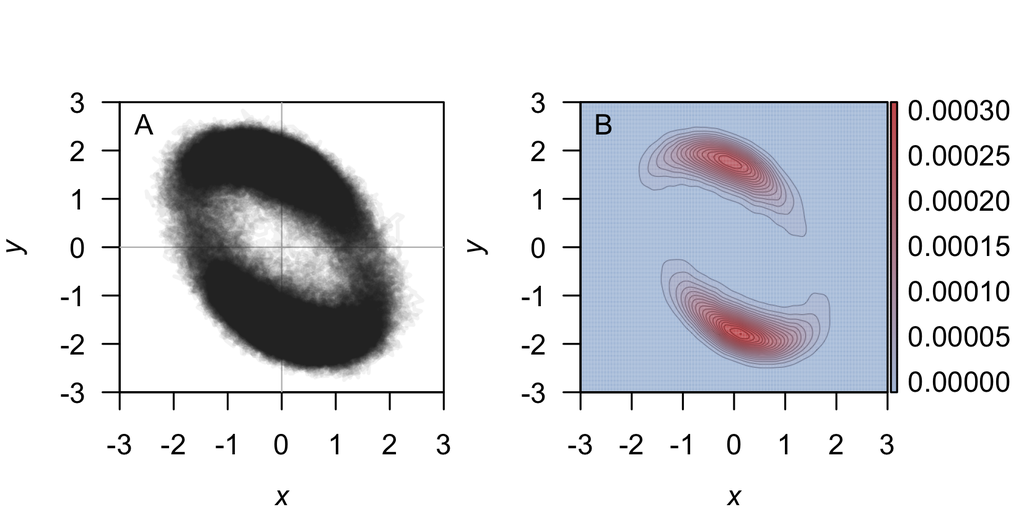

Figure 13: (A) The realization of System @ref(eq:ex3) plotted in $(x,y)$-space with `TSPlot()` with `dim = 2`. (B) A density plot obtained from the realization of System @ref(eq:ex3) by using the function `TSDensity()` with `dim = 2`, `contour.levels = 20`, and `contour.lwd = 0.1`. Red corresponds to high density, and blue to low density.

```r
[commandchars=\\\{\}]
var.eqn.x <- "x * ((1 + alpha1) - (x^2) - x * y - (y^2))"
var.eqn.y <- "y * ((1 + alpha2) - (x^2) - x * y - (y^2))"
model.state <- c(x = 0.5, y = 0.5)
model.parms <- c(alpha1 = 1.25, alpha2 = 2)
model.sigma <- 0.8
model.time <- 5000
model.deltat <- 0.01
ts.ex3 <- TSTraj(y0 = model.state, time = model.time, deltat = model.deltat,
  x.rhs = var.eqn.x, y.rhs = var.eqn.y, parms = model.parms, sigma = model.sigma)
TSPlot(ts.ex3, deltat = model.deltat)                  # Figure \ref{fig:ex3ts}
TSPlot(ts.ex3, deltat = model.deltat, dim = 2 , line.alpha = 25)    # Figure \ref{fig:ex32d}a
TSDensity(ts.ex3, dim = 1)              # Histogram of time series
TSDensity(ts.ex3, dim = 2 , contour.levels = 20 , contour.lwd = 0.1)    # Figure \ref{fig:ex32d}b
```

## Step 3: Local quasi-potential calculation

Two local quasi-potentials need to be calculated, $\Phi_{1}(x,y)$ corresponding to $\mathbf{e}_{s1}$, and $\Phi_{2}(x,y)$ corresponding to $\mathbf{e}_{s2}$. In both cases, sensible boundary and mesh choices are $Lx_{1}=-3,$ $Ly_{1}=-3,$ $Lx_{2}=3,$ $Ly_{2}=3,$ $N_x=6000,$ and $N_y=6000.$

```r
equation.x <- Model2String(var.eqn.x, parms = model.parms)
equation.y <- Model2String(var.eqn.y, parms = model.parms)
bounds.x <- c(-3, 3); bounds.y <- c(-3, 3)
step.number.x <- 6000; step.number.y <- 6000
eq1.x <- 0; eq1.y <- -1.73205
eq2.x <- 0; eq2.y <- 1.73205
eq1.local <- QPotential(x.rhs = equation.x, x.start = eq1.x, x.bound = bounds.x,
  x.num.steps = step.number.x, y.rhs = equation.y, y.start = eq1.y,
  y.bound = bounds.y, y.num.steps = step.number.y)
eq2.local <- QPotential(x.rhs = equation.x, x.start = eq2.x, x.bound = bounds.x,
  x.num.steps = step.number.x, y.rhs = equation.y, y.start = eq2.y,
  y.bound = bounds.y, y.num.steps = step.number.y)
```

## Step 4: Global quasi-potential

```r
ex3.global <- QPGlobal(local.surfaces = list(eq1.local, eq2.local),
  unstable.eq.x = c(0, -1.5, 1.5), unstable.eq.y = c(0, 0, 0), x.bound = bounds.x,
  y.bound = bounds.y)
```

## Step 5: Global quasi-potential visualization

Figure 14 shows a contour plot of the global quasi-potential. Note that the surface is continuous, but not smooth. The lack of smoothness is a generic feature of global quasi-potentials created from pasting local quasi-potentials. Cusps usually form when switching from the part of solution obtained from one local quasi-potential to the other.

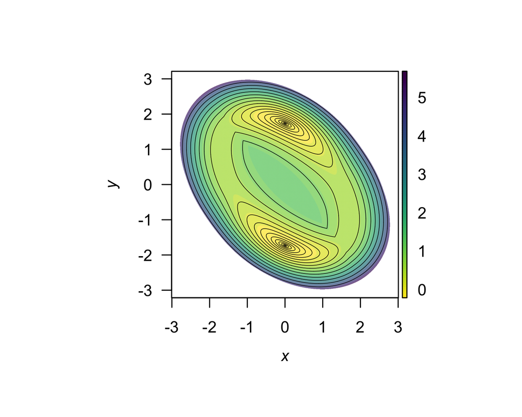

Figure 14: A contour plot of the quasi-potential of System @ref(eq:ex3) using the function `QPContour()`. Yellow corresponds to low values of the quasi-potential, and purple to high values.

```r
QPContour(ex3.global, dens = c(1000, 1000), x.bound = bounds.x, y.bound = bounds.y,
  c.parm = 5)
```

# Boundary behavior

It is important to consider the type of behavior that should be enforced at the boundaries and on coordinate axes ($x=0$ and $y=0$). By default, the ordered-upwind method computes the quasi-potential for the system defined by the user, without regard for the influence of the boundaries or the significance of these axes. In some cases, however, a model is only valid in a subregion of phase space. For example, in many population models, only the non-negative phase space is physically meaningful. In such cases, it is undesirable to allow the ordered-upwind method to consider trajectories that pass through negative phase space. In the default mode for `QPotential()`, if $(x,y)$ lies in positive phase space, $\Phi(x,y)$ can be impacted by the vector field in negative phase space, if the path corresponding to the minimum work passes through negative phase space. The argument `bounce = "d"` corresponds to this (d)efault behavior. A user can prevent the ordered upwind method from passing trajectories through negative phase space by using the option `bounce = "p"` for (p)ositive values only. This option can be interpreted as a reflecting boundary condition. It forces the front of solutions obtained by the ordered upwind method to stay in the defined boundaries, which is positive phase space in this case. A more generic option is `bounce = "b"` for (b)ounce, which allows users to supply reflecting boundaries other than the coordinate axes. These are set with `x.bound` and `y.bound`. Small numerical errors at a reflecting boundary can cause the algorithm to terminate prematurely. To avoid this, the option `bounce.edge` adds a small amount of padding between the reflecting boundary and the edge of the computational domain.

# Different noise terms

In the cases considered so far, the noise terms for the $X$ and $Y$ variables have had identical intensity. This was useful for purposes of illustration in the algorithm, but it will often be not true for real-world systems. Fortunately, *QPot* can accommodate other noise terms with coordinate transforms. Consider a system of the form:
$$\begin{split}
\label{eqsdnt1}
dX(t)&=f_{1}\left(X(t),Y(t)\right)\, dt+\sigma\, g_{1}\, dW_{1}(t)\\
dY(t)&=f_{2}\left(X(t),Y(t)\right)\, dt+\sigma\, g_{2}\, dW_{2}(t).
\end{split} (\#eq:eqsdnt1)$$
$\sigma$ is a scaling parameter that specifies the overall noise intensity. The parameters $g_{1}$ and $g_{2}$ specify the relative intensity of the two noise terms. To transform this system into a form that is usable for *QPot*, make the change of variable $\tilde{X}=g_{1}^{-1}X$ and $\tilde{Y}=g_{2}^{-1}Y.$ In the new coordinates, the drift terms (that is, the terms multiplied by $dt$), are different. These are $\tilde{f_{1}}\left(\tilde{X},\tilde{Y}\right)=g_{1}^{-1}\,f_{1}\left(g_{1}\tilde{X},\,g_{2}\tilde{Y}\right)$ and $\tilde{f_{2}}\left(\tilde{X},\tilde{Y}\right)=g_{2}^{-1}\,f_{2}\left(g_{1}\tilde{X},\,g_{2}\tilde{Y}\right)$. These new drift terms should be used as the deterministic skeleton that is input into *QPot*. After obtaining the global quasi-potential for these transformed coordinates, one can switch back to the original coordinates for plotting.

Many models contain multiplicative noise terms. These are of the form:
$$\begin{split}
\label{eqsdnt2}
dX(t)&=f_{1}\left(X(t),Y(t)\right)\, dt+\sigma\, g_{1}\, X(t)\,
dW_{1}(t)\\
dY(t)&=f_{2}\left(X(t),Y(t)\right)\, dt+\sigma\, g_{2}\, Y(t)\,
dW_{2}(t).
\end{split} (\#eq:eqsdnt2)$$
To transform this system into a form that is usable for *QPot*, make the change of variable $\tilde{X}=g_{1}^{-1}\ln\left(X\right)$ and $\tilde{Y}=g_{2}^{-1}\ln\left(Y\right).$ This is called the Lamperti transform (Iacus 2009). It is not always possible to transform a multidimensional stochastic differential equation with multiplicative noise into one with additive noise (Pavliotis 2014), but in special cases like @ref(eq:eqsdnt2) it is. This coordinate change is non-linear, so Itô’s lemma introduces extra terms into the drift of the transformed equations. If $\sigma$ is small, though, these terms can be discounted, and the new drift terms will remain independent of $\sigma$. These new drift terms can be input into *QPot*. After obtaining the global quasi-potential for these transformed coordinates, one can switch back to the original coordinates.

# Conclusion

*QPot* is an R package that provides several important tools for analyzing two-dimensional systems of stochastic differential equations. Future efforts will work toward extending *QPot* to higher-dimensional systems, but this is a computationally challenging task. *QPot* includes functions for generating realizations of the stochastic differential equations, and for analyzing and visualizing the results. A central component of *QPot* is the calculation of quasi-potential functions, which are highly useful for studying stochastic dynamics. For example, quasi-potential functions can be used to compare the stability of different attractors in stochastic systems, a task that traditional linear stability analysis is poorly suited for (Nolting and Abbott 2016). By offering an intuitive way to quantify attractor stability, quasi-potentials are poised to become an important means of understanding phenomena like metastability and alternative stable states. *QPot* makes quasi-potentials accessible to R users interested in applying this new framework.

# Author contributions

K.C.A, C.M.M., B.C.N., and C.R.S. designed the project. M.K.C. wrote the C code for finding the quasi-potential; C.M.M. and C.R.S. wrote the R code and adapted the C code.

# Acknowledgments

This work was supported by a Complex Systems Scholar grant to K.C.A. from the James S. McDonnell Foundation. M.K.C. was partially supported by NSF grant 1217118. We also thank the anonymous reviewers for their constructive comments and suggestions which helped us to improve the quality of our paper.

Adler, D., D. Murdoch, O. Nenadic, S. Urbanek, M. Chen, A. Gebhardt, B. Bolker, G. Csardi, A. Strzelecki, and A. Senger. 2015. *Rgl: 3D Visualization Device System for R Using OpenGL*. https://CRAN.R-project.org/package=rgl.

Allen, Edward J. 2007. *Modeling with Ito Stochastic Differetnial Equations*. Vol. 22. Mathematical Modelling: Theory and Applications. Springer-Verlag.

Brouste, Alexandre, Masaaki Fukasawa, Hideitsu Hino, Stefano M. Iacus, Kengo Kamatani, Yuta Koike, Hiroki Masuda, et al. 2014. “The YUIMA Project: A Computational Framework for Simulation and Inference of Stochastic Differential Equations.” *Journal of Statistical Software* 57 (4): 1–51. https://doi.org/10.18637/jss.v057.i04.

Cameron, M K. 2012. “Finding the quasipotential for nongradient SDEs.” *Physica D* 241 (18): 1532–50.

Chua, Thomas S. Parker Leon, and Thomas S. Parker. 1989. “Practical Numerical Algorithms for Chaotic Systems.” In. Springer-Verlag.

Collie, Jeremy S, and Paul D Spencer. 1994. “Modeling Predator-Prey Dynamics in a Fluctuating Environment.” *Canadian Journal of Fisheries and Aquatic Sciences* 51 (12): 2665–72.

Freidlin, Mark I, and Alexander D Wentzell. 2012. *Random Perturbations of Dynamical Systems*. Vol. 260. Springer-Verlag.

Garnier, Simon. 2016. *Viridis: Default Color Maps from “Matplotlib”*. https://github.com/sjmgarnier/viridis.

Graham, R, and T Tél. 1986. “Nonequilibrium potential for coexisting attractors.” *Physical Review. A* 33 (2): 1322–37.

Grayling, Michael J. 2014a. “PhaseR: An R Package for Phase Plane Analysis of Autonomous ODE Systems.” *The R Journal* 6 (2): 43–51.

———. 2014b. *PhaseR: Phase Plane Analysis of One and Two Dimensional Autonomous ODE Systems*. https://CRAN.R-project.org/package=phaseR.

Guidoum, A. C., and K. Boukhetala. 2016. *Sim.DiffProc: Simulation of Diffusion Processes.* https://CRAN.R-project.org/package=Sim.DiffProc.

Iacus, Stefano M. 2009. *Simulation and Inference for Stochastic Differential Equations: With r Examples*. Vol. 1. Springer Science & Business Media.

Moore, Christopher, Christopher Stieha, Ben Nolting, Maria Cameron, and Karen Abbott. 2016. *QPot: Quasi-Potential Analysis for Stochastic Differential Equations*. [https://CRAN.R-project.org/package=QPot, https://github.com/bmarkslash7/QPot](https://CRAN.R-project.org/package=QPot,%0A%20%20%20%20%20%20%20%20%20%20%20%20%20%20%20%20%20%20https://github.com/bmarkslash7/QPot).

Nolting, B C, and K C Abbott. 2016. “Balls, Cups, and Quasi-Potentials: Quantifying Stability in Stochastic Systems.” *Ecology* 97 (4): 850–64.

Pavliotis, Grigorios A. 2014. *Stochastic Processes and Applications: Diffusion Processes, the Fokker-Planck and Langevin Equations*. Vol. 60. Texts in Applied Mathematics. New York: Springer-Verlag.

Roy, R V, and E Nauman. 1995. “Noise-Induced Effects on a Non-Linear Oscillator.” *Journal of Sound and Vibration* 183 (2): 269–95. https://doi.org/10.1006/jsvi.1995.0254.

Sethian, J. A., and A. Vladimirsky. 2001. “Ordered Upwind Methods for Static Hamilton-Jacobi Equations.” *Proceedings of the National Academy of Sciences* 98 (20): 11069–74. https://doi.org/10.1073/pnas.201222998.

Sethian, James A., and Alexander Vladimirsky. 2003. “Ordered Upwind Methods for Static Hamilton-Jacobi Equations: Theory and Algorithms.” *SIAM Journal on Numerical Analysis* 41 (1): 325–63. https://doi.org/10.1137/S0036142901392742.

Soetaert, Karline. 2014. *Plot3D: Plotting Multi-Dimentional Data in R*. https://CRAN.R-project.org/package=plot3D.

Soetaert, Karline, and Peter MJ Herman. 2008. *A Practical Guide to Ecological Modelling: Using R as a Simulation Platform*. Springer Science & Business Media.

Soetaert, Karline, Thomas Petzoldt, and R. Woodrow Setzer. 2010. “Solving Differential Equations in R: Package deSolve.” *Journal of Statistical Software* 33 (9): 1–25. https://doi.org/10.18637/jss.v033.i09.

Steele, J H, and E W Henderson. 1981. “A Simple Plankton Model.” *American Naturalist* 117 (5): 676–91.